# Math 253

# Topic 1 Exercises

2.4.1 - Flexible versus Inflexible Models a. The sample size n is extremely large and the number of predictors p is small.

A flexible model would be better situation. Because n is large, the chances of overfitting are low even when using a flexible model. At the same time, flexible models tend to reduce bias that an inflexible model would not be able to do.

2. The number of predictors p is extremly large and the sample size n is extremely small.

An inflexible model works better here. Because the sample size is small, using a flexible model would cause a larger increase in variance in comparison to the reduction in bias by using a flexible model. Because of the increase in variance being larger the reduction in bias, this would result in an overfitting if using a flexible model. Thus, inflexible models are better in this case.

3. The relationship between predictors and responses are highly non-linear.

A flexible model is needed here because a flexible model will be able to capture the non-linear effect, whereas inflexible models would not.

4. The variance of error terms is extremely high.

An inflexible model would work better in this case, since a flexible model would capture too much of the “noise” in the data due to the higher variance in the error terms. So, a inflexible model would better address data with high variance in error terms in this case.

2.4.2 a) Based on the data from several companies, this is a regression problem, since we are interested in knowing how each variable (profit, number of employees, and industry) affects a CEO’s salary in a quantitative way. Since we are interested in learning more aobut these possible relationships, the main purpose of this model would be for inference instead of prediction.

2. This is a classification problem since there are two possible outputs for this model: success or failure. We are interested in prediction in this case, since we want to better able to predict if this product would be a success or failure if brought to market.
3. This is also a regression problem since we are interested in predicting the % change of the U.S. dollar, which can have several different possible output results unlike a classification problem. This model is concerned with prediction over inference, as we are concerned with predicting how much/little the % change of the U.S. dollar is affected by the other variables mentioned in the data.

2.4.3 a) I couldn’t figure out how to sketch these error graphs in R. So I just looked them up online. b) The reason for the different shape of the curves is due to the way each curve attempts to address the issue of variance and bias in data. This can be plotted with flexibility on the X axis, which will give us a better understanding of how flexible/inflexible models affect these measures.

2.4.8

```r
college = read.csv("College.csv",header=T)
#fix(college)
#View(college)
#rownames(college)=college[,1]
#fix(college)
#college=college[,1]
#View(college)
summary(college)
```

```
##                             X       Private        Apps
##  Abilene Christian University:  1   No :212   Min.   :   81
##  Adelphi University          :  1   Yes:565   1st Qu.:  776
##  Adrian College              :  1             Median : 1558
##  Agnes Scott College         :  1             Mean   : 3002
##  Alaska Pacific University   :  1             3rd Qu.: 3624
##  Albertson College           :  1             Max.   :48094
##  (Other)                     :771
##      Accept          Enroll       Top10perc       Top25perc
##  Min.   :   72   Min.   :  35   Min.   : 1.00   Min.   :  9.0
##  1st Qu.:  604   1st Qu.: 242   1st Qu.:15.00   1st Qu.: 41.0
##  Median : 1110   Median : 434   Median :23.00   Median : 54.0
##  Mean   : 2019   Mean   : 780   Mean   :27.56   Mean   : 55.8
##  3rd Qu.: 2424   3rd Qu.: 902   3rd Qu.:35.00   3rd Qu.: 69.0
##  Max.   :26330   Max.   :6392   Max.   :96.00   Max.   :100.0
##
##   F.Undergrad     P.Undergrad         Outstate       Room.Board
##  Min.   :  139   Min.   :    1.0   Min.   : 2340   Min.   :1780
##  1st Qu.:  992   1st Qu.:   95.0   1st Qu.: 7320   1st Qu.:3597
##  Median : 1707   Median :  353.0   Median : 9990   Median :4200
##  Mean   : 3700   Mean   :  855.3   Mean   :10441   Mean   :4358
##  3rd Qu.: 4005   3rd Qu.:  967.0   3rd Qu.:12925   3rd Qu.:5050
##  Max.   :31643   Max.   :21836.0   Max.   :21700   Max.   :8124
##
##      Books           Personal         PhD            Terminal
##  Min.   :  96.0   Min.   : 250   Min.   :  8.00   Min.   : 24.0
##  1st Qu.: 470.0   1st Qu.: 850   1st Qu.: 62.00   1st Qu.: 71.0
##  Median : 500.0   Median :1200   Median : 75.00   Median : 82.0
##  Mean   : 549.4   Mean   :1341   Mean   : 72.66   Mean   : 79.7
##  3rd Qu.: 600.0   3rd Qu.:1700   3rd Qu.: 85.00   3rd Qu.: 92.0
##  Max.   :2340.0   Max.   :6800   Max.   :103.00   Max.   :100.0
##
##    S.F.Ratio      perc.alumni        Expend        Grad.Rate
##  Min.   : 2.50   Min.   : 0.00   Min.   : 3186   Min.   : 10.00
##  1st Qu.:11.50   1st Qu.:13.00   1st Qu.: 6751   1st Qu.: 53.00
##  Median :13.60   Median :21.00   Median : 8377   Median : 65.00
##  Mean   :14.09   Mean   :22.74   Mean   : 9660   Mean   : 65.46
##  3rd Qu.:16.50   3rd Qu.:31.00   3rd Qu.:10830   3rd Qu.: 78.00
##  Max.   :39.80   Max.   :64.00   Max.   :56233   Max.   :118.00
##
```

[figure not shown]

```r
A = matrix(college)
pairs(college[1:10,])
```

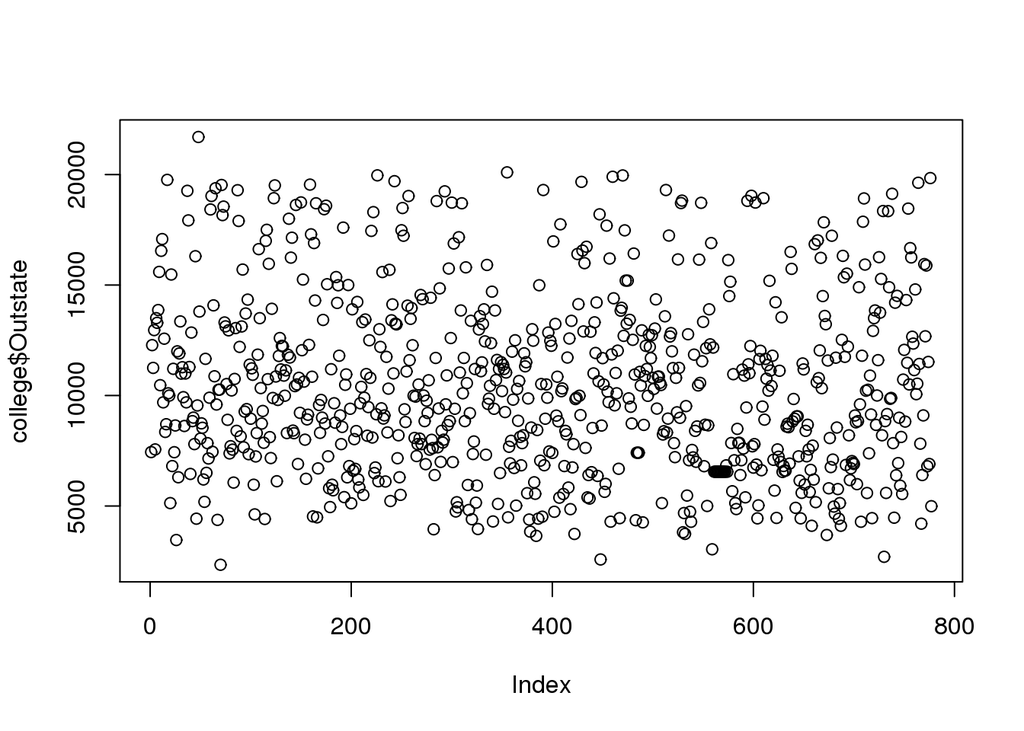

```r
plot(college$Outstate)
```

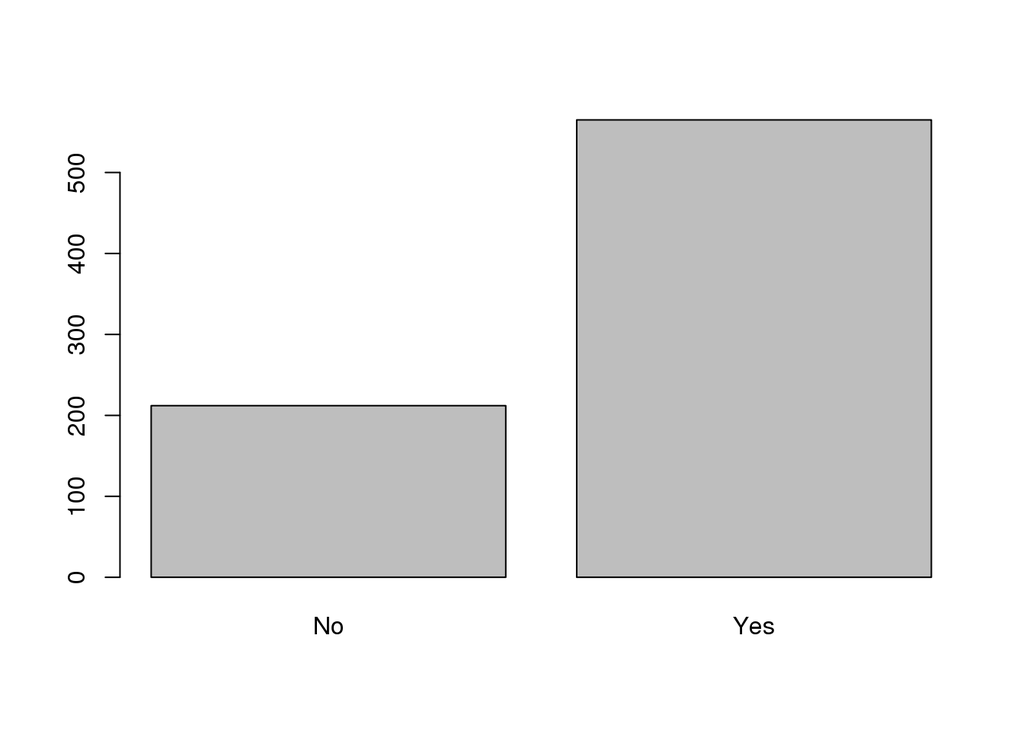

```r
plot(college$Private)
```

```r
Elite=rep("No",nrow(college ))
Elite[college$Top10perc >50]=" Yes"
Elite=as.factor(Elite)
college=data.frame(college , Elite)
summary(Elite)
```

```
##  Yes   No
##   78  699
```

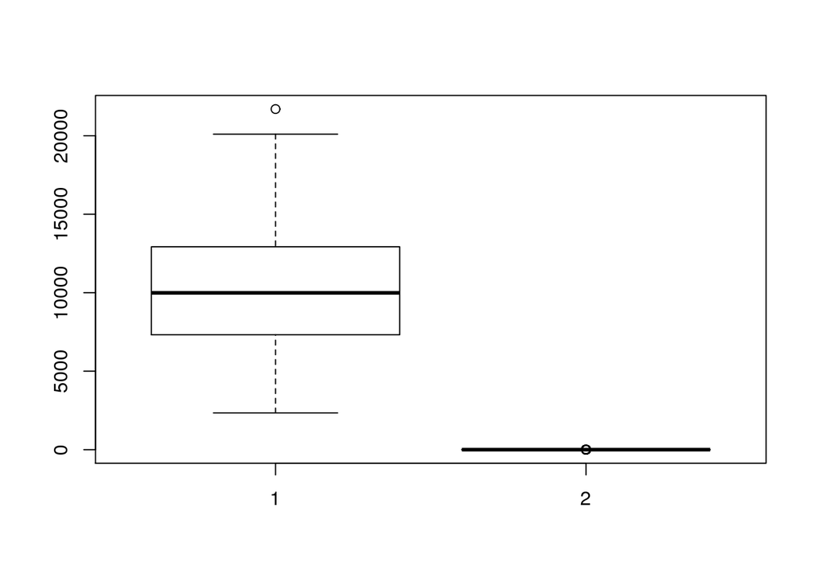

```r
boxplot(college$Outstate,Elite)
```

```r
summary(college)
```

```
##                             X       Private        Apps
##  Abilene Christian University:  1   No :212   Min.   :   81
##  Adelphi University          :  1   Yes:565   1st Qu.:  776
##  Adrian College              :  1             Median : 1558
##  Agnes Scott College         :  1             Mean   : 3002
##  Alaska Pacific University   :  1             3rd Qu.: 3624
##  Albertson College           :  1             Max.   :48094
##  (Other)                     :771
##      Accept          Enroll       Top10perc       Top25perc
##  Min.   :   72   Min.   :  35   Min.   : 1.00   Min.   :  9.0
##  1st Qu.:  604   1st Qu.: 242   1st Qu.:15.00   1st Qu.: 41.0
##  Median : 1110   Median : 434   Median :23.00   Median : 54.0
##  Mean   : 2019   Mean   : 780   Mean   :27.56   Mean   : 55.8
##  3rd Qu.: 2424   3rd Qu.: 902   3rd Qu.:35.00   3rd Qu.: 69.0
##  Max.   :26330   Max.   :6392   Max.   :96.00   Max.   :100.0
##
##   F.Undergrad     P.Undergrad         Outstate       Room.Board
##  Min.   :  139   Min.   :    1.0   Min.   : 2340   Min.   :1780
##  1st Qu.:  992   1st Qu.:   95.0   1st Qu.: 7320   1st Qu.:3597
##  Median : 1707   Median :  353.0   Median : 9990   Median :4200
##  Mean   : 3700   Mean   :  855.3   Mean   :10441   Mean   :4358
##  3rd Qu.: 4005   3rd Qu.:  967.0   3rd Qu.:12925   3rd Qu.:5050
##  Max.   :31643   Max.   :21836.0   Max.   :21700   Max.   :8124
##
##      Books           Personal         PhD            Terminal
##  Min.   :  96.0   Min.   : 250   Min.   :  8.00   Min.   : 24.0
##  1st Qu.: 470.0   1st Qu.: 850   1st Qu.: 62.00   1st Qu.: 71.0
##  Median : 500.0   Median :1200   Median : 75.00   Median : 82.0
##  Mean   : 549.4   Mean   :1341   Mean   : 72.66   Mean   : 79.7
##  3rd Qu.: 600.0   3rd Qu.:1700   3rd Qu.: 85.00   3rd Qu.: 92.0
##  Max.   :2340.0   Max.   :6800   Max.   :103.00   Max.   :100.0
##
##    S.F.Ratio      perc.alumni        Expend        Grad.Rate
##  Min.   : 2.50   Min.   : 0.00   Min.   : 3186   Min.   : 10.00
##  1st Qu.:11.50   1st Qu.:13.00   1st Qu.: 6751   1st Qu.: 53.00
##  Median :13.60   Median :21.00   Median : 8377   Median : 65.00
##  Mean   :14.09   Mean   :22.74   Mean   : 9660   Mean   : 65.46
##  3rd Qu.:16.50   3rd Qu.:31.00   3rd Qu.:10830   3rd Qu.: 78.00
##  Max.   :39.80   Max.   :64.00   Max.   :56233   Max.   :118.00
##
##   Elite
##   Yes: 78
##  No  :699
##
##
##
##
##
```

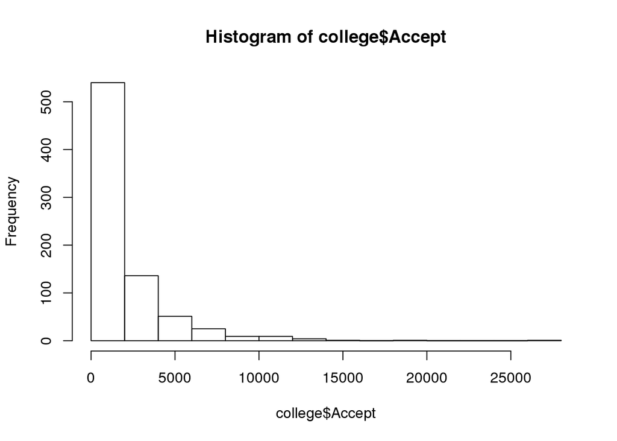

```r
hist(college$Accept,15)
```

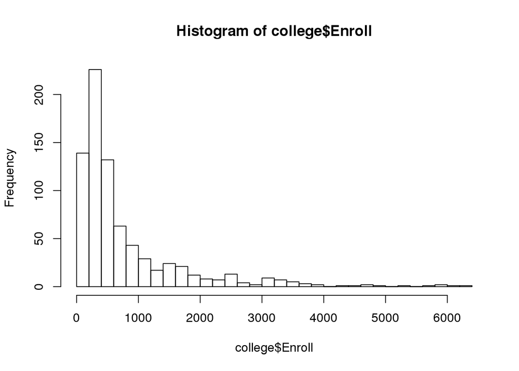

```r
hist(college$Enroll,25)
```

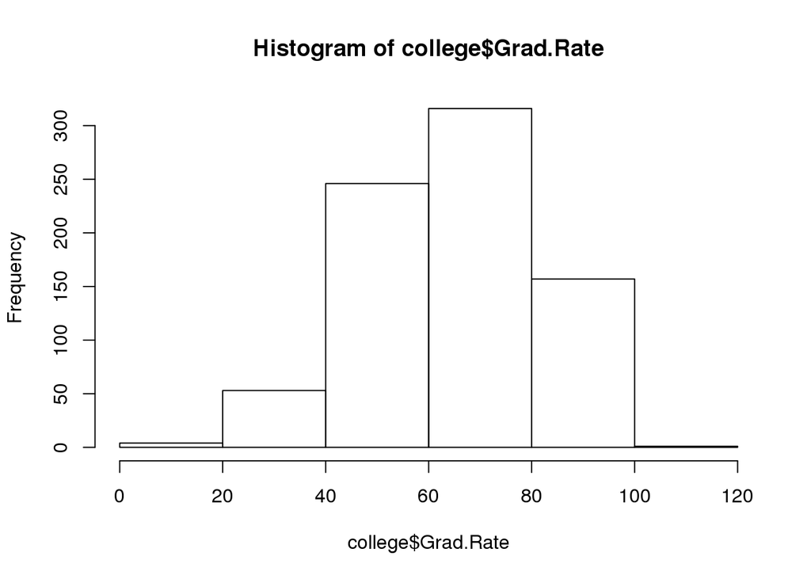

```r
hist(college$Grad.Rate,5)
```

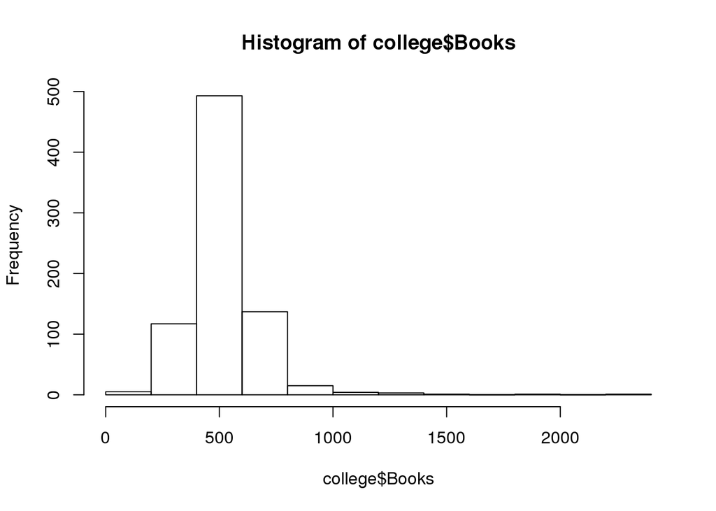

```r
hist(college$Books,10)
```

```r
par(mfrow=c(2,2))
```

2.4.6 A parametric statistical learning approach uses the assumption that the sample data is from a probability distribution with fixed parameters, whereas a non-parametric approach allows parameters to increase or decrease.

2.4.7 a) Calculating Euclidean distance: Square root of sum of squares for each observation From the origin, the distances are as follows: Observation 1: 3, Observation 2: 2, Observation 3: 3.16, Observation 4: 2.24, Observation 5: 1.41, Observation 6: 1.73 b) Our prediction for K=1 is Green c) Our prediction for K=3 is Red d) If the Bayes decision boundary is highly non-linear, then best value for K is high. This is true because K needs to be high in order to capture the non-linear effect in the Bayes decision boundary is highly non-linear.

2.4.9

```r
auto = read.csv("Auto.csv",header=TRUE)
range(auto$mpg)
```

```
## [1]  9.0 46.6
```

```r
range(auto$year)
```

```
## [1] 70 82
```

```r
range(auto$cylinders)
```

```
## [1] 3 8
```

```r
range(auto$displacement)
```

```
## [1]  68 455
```

```r
#range(auto$horsepower)
range(auto$weight)
```

```
## [1] 1613 5140
```

```r
range(auto$acceleration)
```

```
## [1]  8.0 24.8
```

```r
range(auto$origin)
```

```
## [1] 1 3
```

```r
#range(auto$name)
```

```r
mean(auto$mpg)
```

```
## [1] 23.51587
```

```r
mean(auto$cylinders)
```

```
## [1] 5.458438
```

```r
mean(auto$displacement)
```

```
## [1] 193.5327
```

```r
mean(auto$horsepower)
```

```
## [1] NA
```

```r
mean(auto$weight)
```

```
## [1] 2970.262
```

```r
mean(auto$acceleration)
```

```
## [1] 15.55567
```

```r
mean(auto$origin)
```

```
## [1] 1.574307
```

```r
mean(auto$name)
```

```
## [1] NA
```

```r
standard_deviations = c(sd(auto$mpg),sd(auto$cylinders),sd(auto$displacement),sd(auto$horsepower),sd(auto$weight),sd(auto$acceleration),sd(auto$year),sd(auto$origin),sd(auto$name))
standard_deviations
```

```
## [1]   7.8258039   1.7015770 104.3795833  29.8626969 847.9041195   2.7499953
## [7]   3.6900049   0.8025495  89.2924330
```

```r
newauto = auto[10:85,]
range(newauto$mpg)
```

```
## [1]  9 35
```

```r
range(newauto$year)
```

```
## [1] 70 72
```

```r
range(newauto$cylinders)
```

```
## [1] 3 8
```

```r
range(newauto$displacement)
```

```
## [1]  70 455
```

```r
#range(newauto$horsepower)
range(newauto$weight)
```

```
## [1] 1613 5140
```

```r
range(newauto$acceleration)
```

```
## [1]  8.0 23.5
```

```r
range(newauto$origin)
```

```
## [1] 1 3
```

```r
#range(newauto$name)
mean(newauto$mpg)
```

```
## [1] 19.61842
```

```r
mean(newauto$cylinders)
```

```
## [1] 5.828947
```

```r
mean(newauto$displacement)
```

```
## [1] 220.9145
```

```r
mean(newauto$horsepower)
```

```
## [1] NA
```

```r
mean(newauto$weight)
```

```
## [1] 3123.579
```

```r
mean(newauto$acceleration)
```

```
## [1] 14.84868
```

```r
#mean(anewuto$origin)
mean(newauto$name)
```

```
## [1] NA
```

```r
new_standard_deviations = c(sd(newauto$mpg),sd(newauto$cylinders),sd(newauto$displacement),sd(newauto$horsepower),sd(newauto$weight),sd(newauto$acceleration),sd(newauto$year),sd(newauto$origin),sd(newauto$name))
```

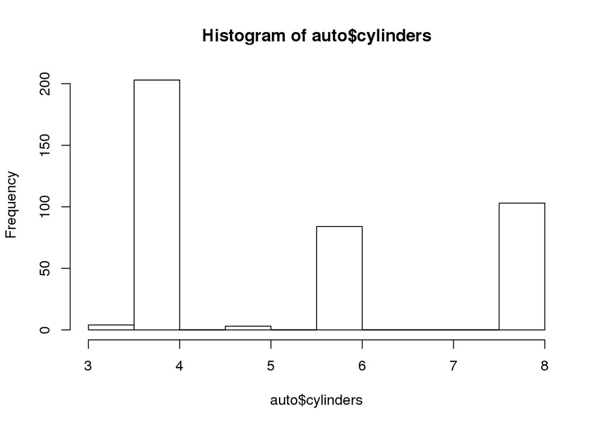

```r
hist(auto$cylinders)
```

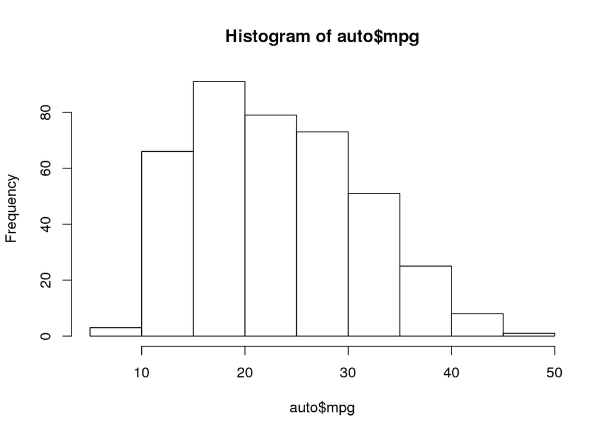

```r
hist(auto$mpg)
```

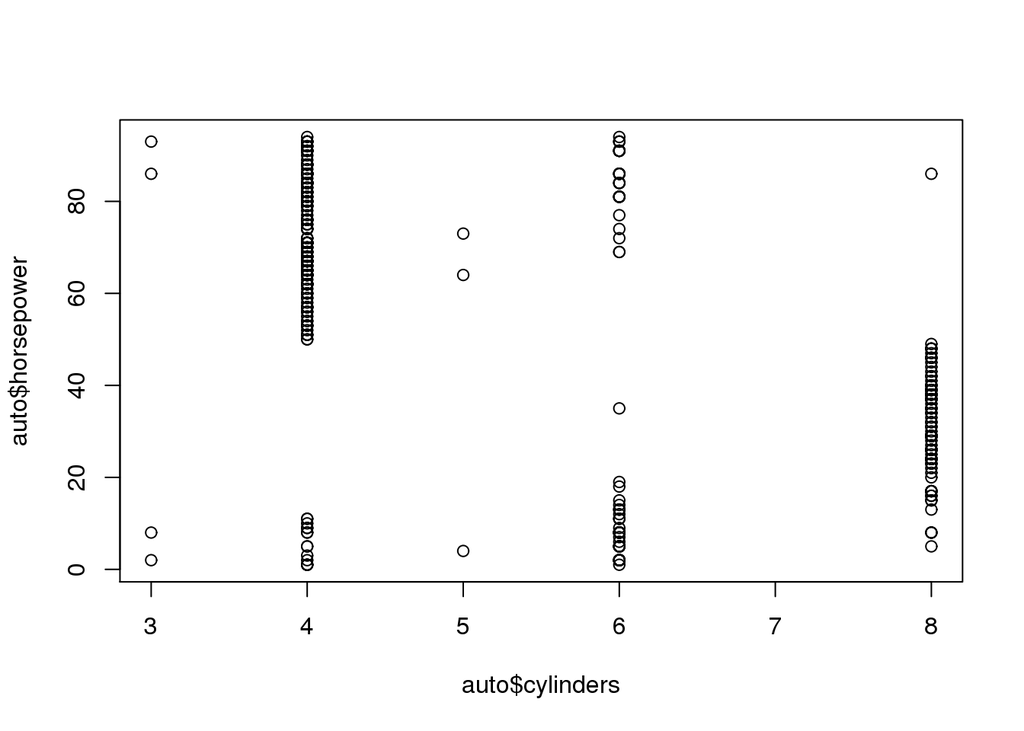

```r
plot(auto$cylinders,auto$horsepower)
```

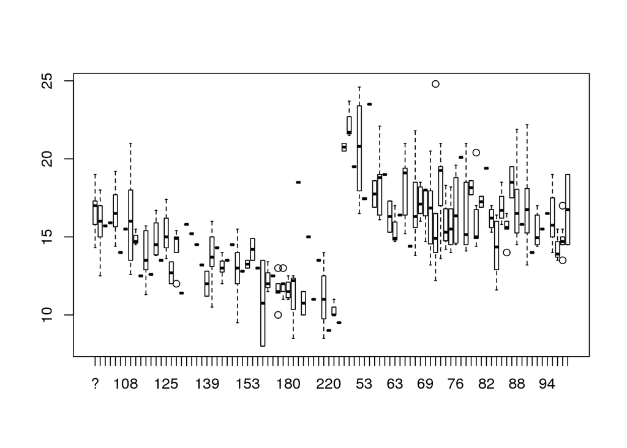

```r
plot(auto$horsepower,auto$acceleration)
```

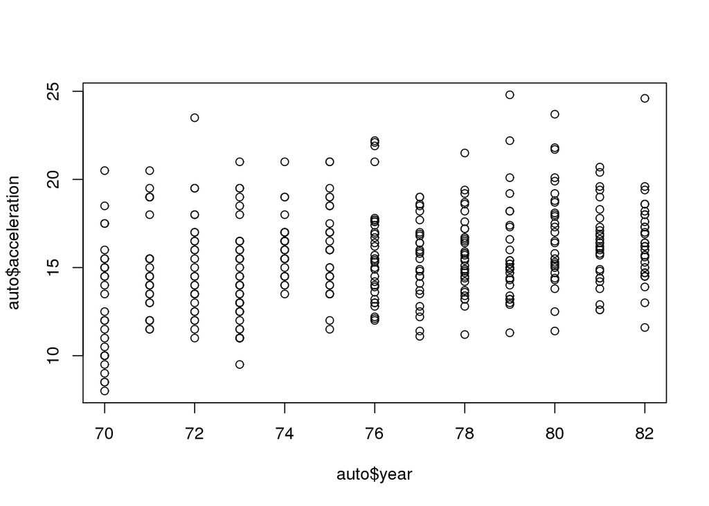

```r
plot(auto$year,auto$acceleration)
```

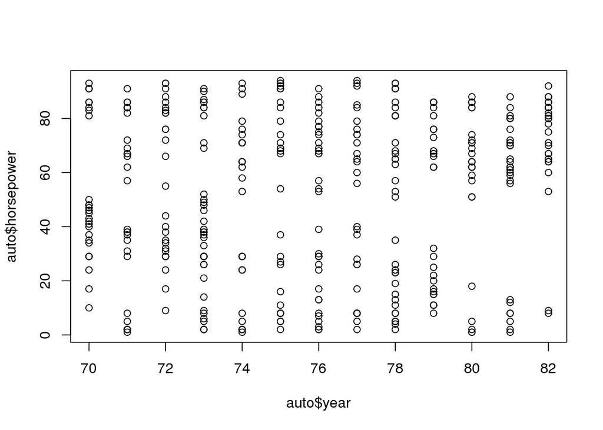

```r
plot(auto$year,auto$horsepower)
```

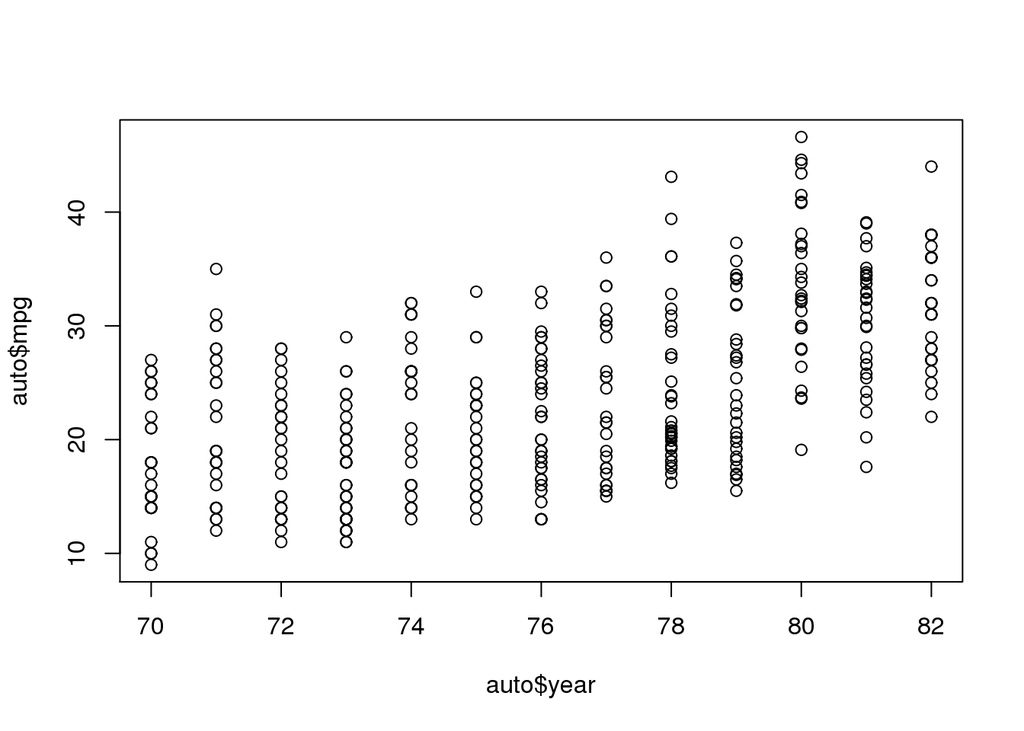

```r
plot(auto$year,auto$mpg)
```

Based off these plots, it seems as though much of the data is quite “noisy”. That is, there are very few clear patterns in the data between many of the variables, which can be seen clearly by the scatterplots above. The histogram of the distribution for miles per gallon was also interesting, as it displays that most cars from the dataset had mpg’s ranging from 10-40 miles per gallon.

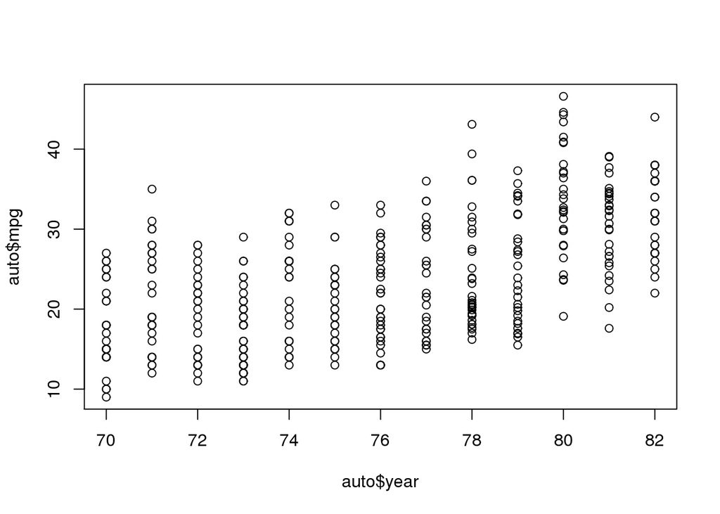

```r
plot(auto$year,auto$mpg)
```

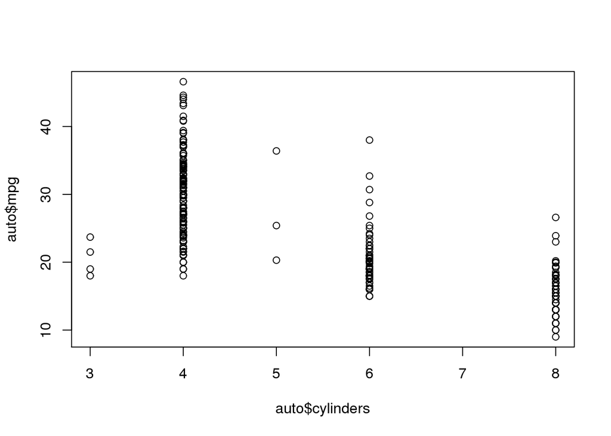

```r
plot(auto$cylinders,auto$mpg)
```

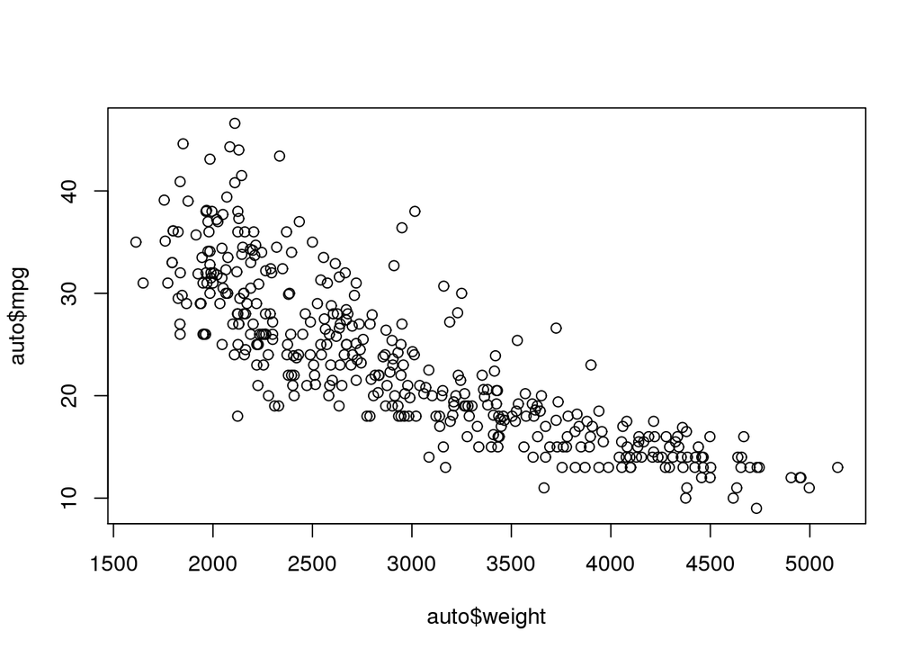

```r
plot(auto$weight,auto$mpg)
```

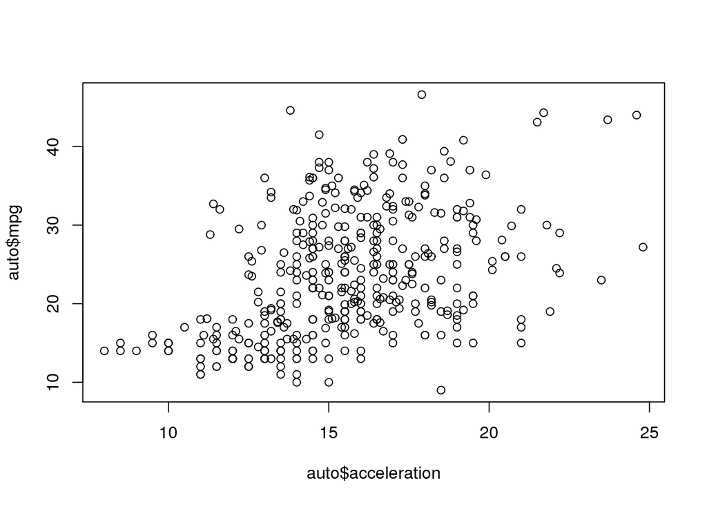

```r
plot(auto$acceleration,auto$mpg)
```

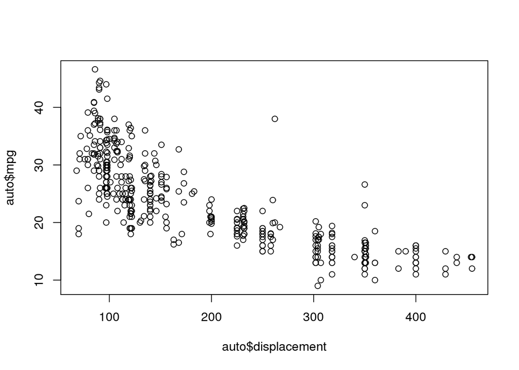

```r
plot(auto$displacement,auto$mpg)
```

Based off these graphs, it seems that weight and displacement have negative effects on a car’s mile per gallon while acceleration seems to have a possible positive effect. Though noisy, it seems that the amount of cyclinders could have a negative effect on a car’s mpg as well.